# Part_II_slide_deck_template slides

## Investigation Overview

This presentation focuses on select features of interest to me in the Prosper loan dataset, particularly reationships between these features and how they correlate. Features of interest to me in this dataset can largely be said to fall under two categories; the borrowers information, like borrower's employment status, monthly income and others. Then the loan information like loan original amount, terms, etc. these are explored using visualizations to highlight key trends and insights.

## Dataset Overview

This analysis explores a dataset that contains loan information of 113,937 loans with 81 variables on each loan, including loan amount, borrower rate (or interest rate), current loan status, borrower income, and many others. For the purpose of this analysis I trimmed down the original dataset provided by udacity to few variables of interest for my analysis, this reduced the dataset features from 81 to 26.

# Part II - Prosper Loan Data Exploration

## by Gideon Ithenumah

#### Borrower's Emplyment Status

Most loans are given to employed individuals with a total of 59%, which is higher than other categories put together. This makes sense because they stand a better chance of repayment.

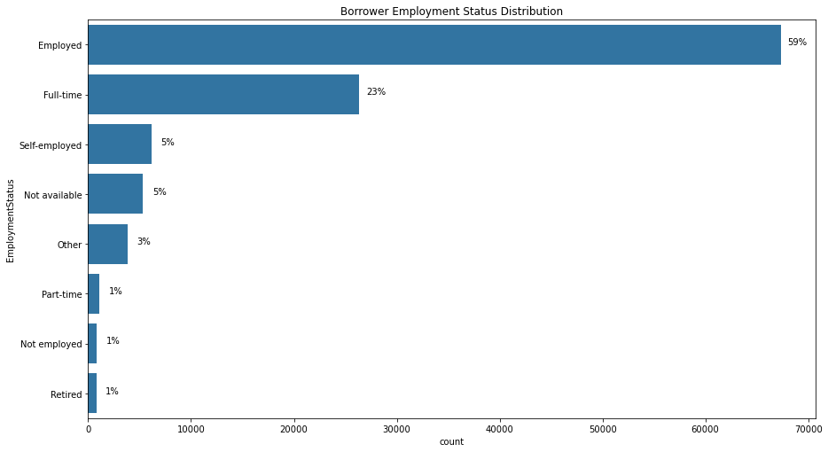

#### Borrower's Occupation

Asides the borrowers whose occupation was not specified, it is seen that Professionals take the most loans.

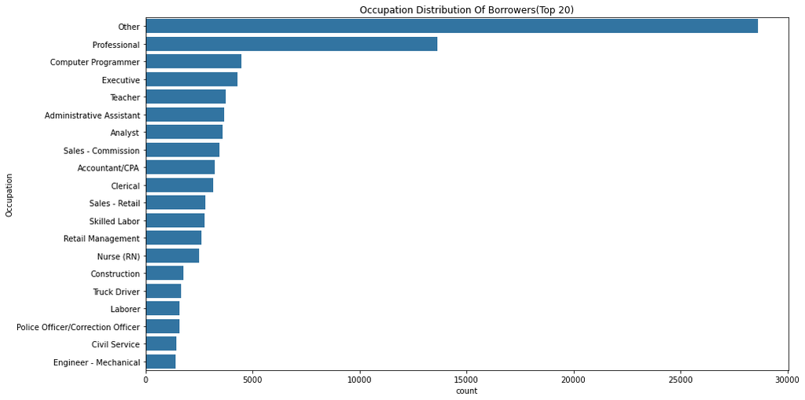

#### Distribution Of Income Range

People with yearly income range between 25,000 and 49,999 dollars take out loans the most.

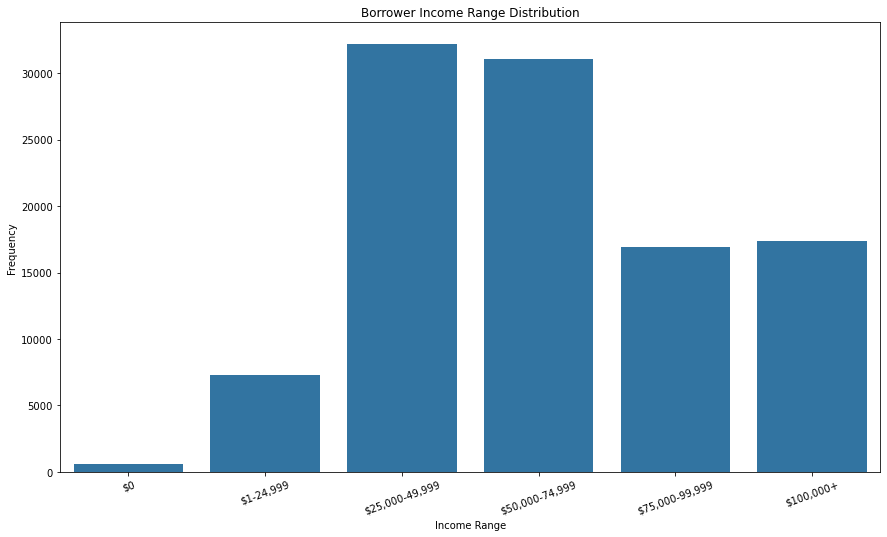

#### Stated Monthly Income

From the visualization it is seen that most of the borrower's monthly income is around 3,000 to 5,000 dollars.

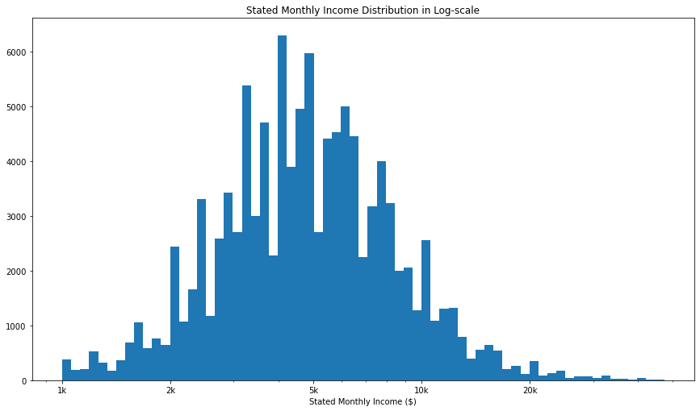

#### Loan Origianal Amount Vs Monthly Loan Payment

Relationship between these two features show that the higher the loan taken the higher the momthly payment required.

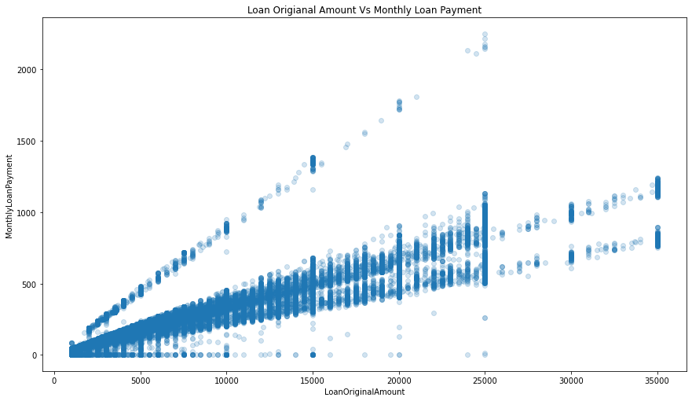

#### Loan Orignal Amount Vs Employment Status

Analysis of these two features show that employed borrowers are entitled to larger loan sums.

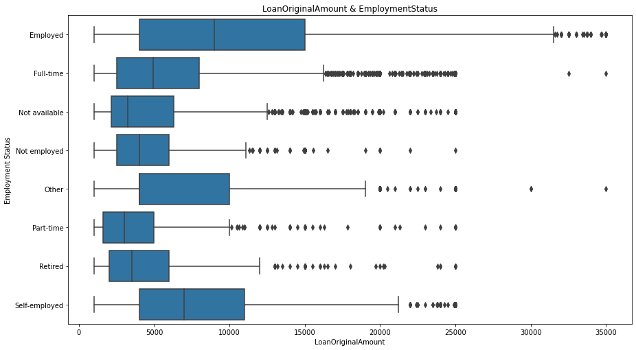

#### LoanStatus Vs BorrowerAPR By EmploymentStatus

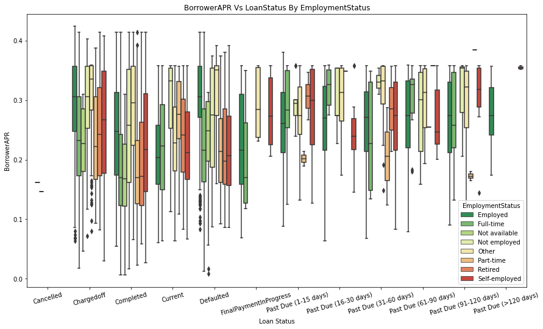